# Natual Language Processing

# NLP Process

After conducting EDA on our Diabetes Reddit comments/submissions, the next step is to conduct natural language processing (NLP) on our datasets. Here is a data analysis workflow diagram.

[figure not shown]

(Workflow Diagram

Where we input our text data into an NLP preprocessing pipeline, the pipeline processes text data by cleaning and standardizing both comments and submissions. For submissions, it first merges the title and self-text into a unified text field, while comments are processed directly from their corresponding body content. The text then goes through a sequential cleaning process that converts it into a structured document format, breaks it down into individual words, standardizes the text by removing special characters and converting to lowercase, and finally reduces words to their root form through lemmatization. Then we employ the term frequency-inverse document frequency (TF-IDF) on the cleaned dataset to extract words with higher TF-IDF scores, and then use these insights to create dummy variables for sentiment modeling. The sentiment modeling involves using a pre-trained sentiment model: sentimentdl_use_twitter, and we also developed the sentiment model pipeline. Then we extract the sentiment results and create visualizations and data tables to answer our research questions in EDA.

# Analysis Report

## TF-IDF Results

here are the outputting wordclouds to represent high TF-IDF scores words for both comments and submissions.

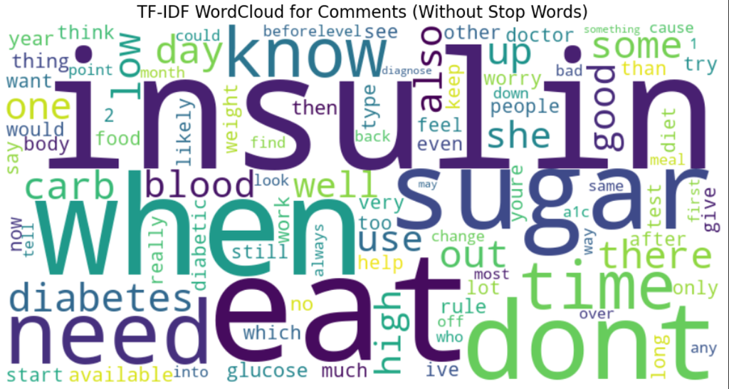

TF-IDF Results for Comments

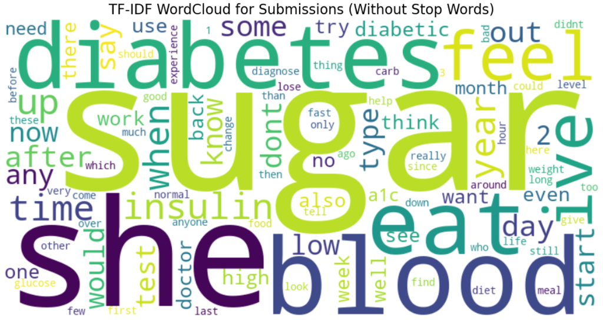

TF-IDF Results for Submissions

As we can see from the wordclouds for both comments and submissions, words like insulin, eat, sugar, diabetes, carb, and blood appear to be the words with high TF-IDF scores. In general, when a word has a high TF-IDF score, it means that the word appears frequently in specific documents but is relatively rare across the entire dataset, suggesting it is a distinctive and meaningful term for those particular discussions. Therefore, these words would be crucial, especially when answering the research questions. From the wordcloud, we can see that people in this subreddit mainly focus on “medication” related subjects and “lifestyle” related subjects.

In our dummy variables creation process, for medications, we track various drug classes including insulins, metformin, GLP-1 receptor agonists (like semaglutide), DPP-4 inhibitors, SGLT2 inhibitors, sulfonylureas, thiazolidinediones, and alpha-glucosidase inhibitors. For lifestyle factors, we track diet and exercise, along with common diabetes symptoms including fatigue, thirst, blurred vision, and frequent urination. Technology-related discussions are captured through mentions of glucose monitors, insulin pumps, smartwatches, and diabetes management apps. A detailed dummy variables table is provided below. A detailed dummy variables table is provided below.

| Category | Subcategory | Components |
| --- | --- | --- |
| Medications | Insulin | insulin, humalog, lantus, novolog, levemir, tresiba, toujeo, basaglar, admelog, apidra, fiasp |
|  | Metformin | metformin, glucophage, fortamet, glumetza, riomet, glycon |
|  | GLP-1 | ozempic, wegovy, semaglutide, rybelsus |
|  | Other GLP-1 | trulicity, dulaglutide, victoza, liraglutide, byetta, exenatide, bydureon, mounjaro, tirzepatide |
|  | DPP-4 Inhibitors | januvia, sitagliptin, tradjenta, linagliptin, nesina, alogliptin, onglyza, saxagliptin, galvus, vildagliptin |
|  | SGLT2 Inhibitors | farxiga, dapagliflozin, jardiance, empagliflozin, invokana, canagliflozin, steglatro, ertugliflozin |
|  | Sulfonylureas | glipizide, glucotrol, glimepiride, amaryl, glyburide, diabeta, glynase, micronase, glibenclamide |
|  | TZDs | actos, pioglitazone, avandia, rosiglitazone |
|  | Alpha-glucosidase | precose, acarbose, glyset, miglitol |
| Lifestyle | Diet | diet, nutrition, healthy eating, keto, ketogenic |
|  | Exercise | exercise, gym, fitness, workout, training, weightlifting, walking, steps |
| Symptoms | Physical | fatigue, tiredness, exhaustion |
|  | Physiological | thirst, dehydration |
|  | Vision | blurred vision, blurry eyesight |
|  | Urinary | frequent urination, peeing often |
| Diabetes Types | Type 1 | type 1, type-1, t1d |
|  | Type 2 | type 2, type-2, t2d |
|  | Gestational | gestational diabetes, pregnancy diabetes |
| Technology | Monitoring | glucose monitor, CGM, continuous glucose monitor |
|  | Insulin Delivery | pump, insulin pump |
|  | Wearables | smartwatch, wearable |
|  | Software | diabetes app, blood sugar tracker, mobile app, software |

## Sentiment Model

After the dummy variable creation, we processed the transformed datasets through a pre-trained sentiment model. The model, **sentimentdl_use_twitter**, which is trained with social media text data, is perhaps the best-suited model for our Reddit text data. After running the model, we extracted the sentiment model results and aggregated associated datasets to answer our research questions.

### Research Question 1: Comparison of Sentiments towards Medication and Lifestyle Changes

During the TF-IDF process, key words such as insulin and eat emerged, demonstrating two primary categories: medication and lifestyle factors. These categories represent the most effective treatments for diabetes and align with our interest in investigating sentiment differences towards these approaches. We aggregated the sentiments for both the medication category and lifestyle factors (detailed in the dummy variables creation table). The aggregated sentiments are visualized using stacked bar charts, where blue indicates positive sentiments, yellow represents neutral sentiment, and red denotes negative sentiment.

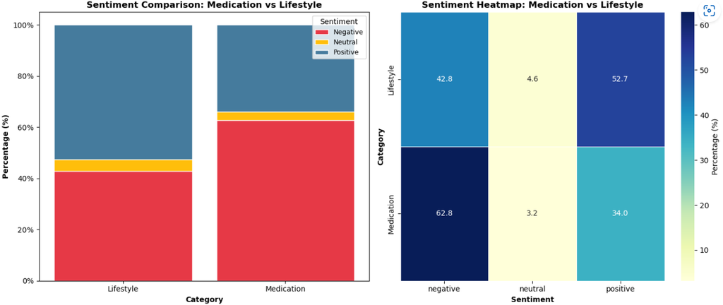

Comparison of Sentiments towards Medication and Lifestyle Changes

### Research Question 2: Comparison of Sentiments towards Different Kinds of Medication

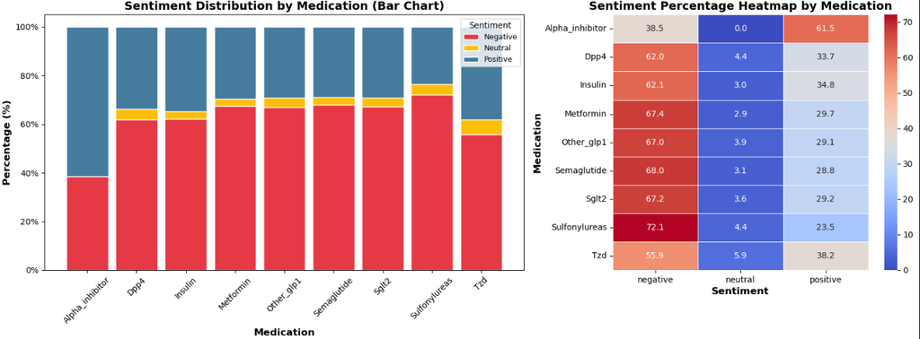

Comparison of Sentiments towards Different Kinds of Medication

This finding is both interesting and counter-intuitive, as alpha inhibitors are not typically the first-line treatment for diabetes, nor do they directly influence insulin production in the body (Vijan and Hayward 2002). The notably positive sentiment toward alpha inhibitors could be attributed to two factors: potential class imbalances in the data, or their unique mechanism of action. Since alpha inhibitors don’t interact directly with insulin, patients might prefer them over first-line medications due to concerns about potential side effects, viewing alpha inhibitors as a gentler approach to glucose management. These insights could be valuable for healthcare specialists in understanding patient perspectives on medications and developing more effective educational strategies about the safety and necessity of various diabetes treatments.

### Research Question 3: Comparison of Sentiments towards Diabetes and Related Symptoms

For this research question, we analyzed how Reddit users in the diabetes subreddit perceive different types of diabetes and their symptoms. We compared the four most common symptoms of diabetes: fatigue, thirst, blurred vision, and frequent urination, alongside three major diabetes categories: gestational diabetes, type 1 diabetes, and type 2 diabetes. The results reveal that users express the most negative sentiments towards blurred vision and gestational diabetes. These insights could inform approaches to improving quality of life for diabetes patients, such as developing targeted symptom-relief medications or educating the public about preventing the progression of diabetes to these more concerning symptoms.

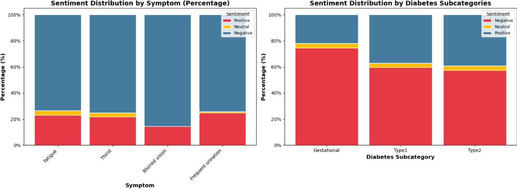

Comparison of Sentiments towards Diabetes and Related Symptoms

### Research Question 4: Overall Sentiments Trend

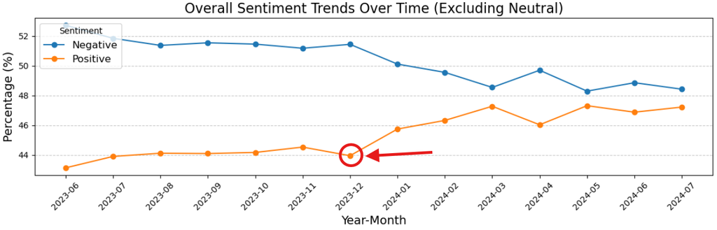

Overall Sentiments Trend

### Research Question 5: Comparison of Sentiments towards Technologies

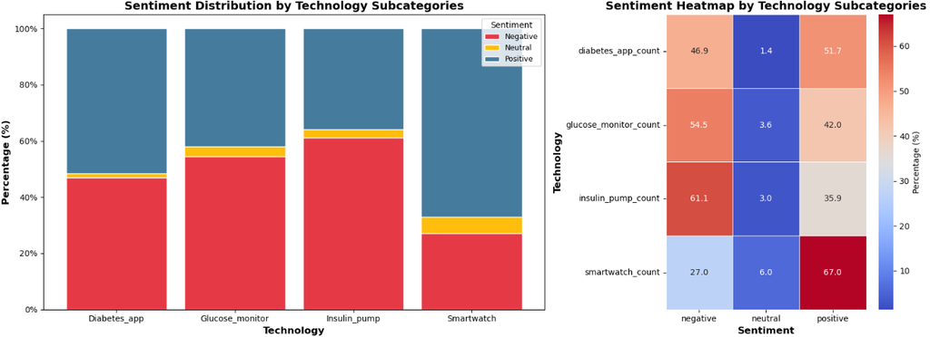

Comparison of Sentiments towards Technologies

For this research question, we investigated sentiments regarding four popular diabetes management technologies: mobile applications, glucose monitors, insulin pumps, and smartwatches. The results were unexpected, with smartwatches receiving the highest positive sentiment despite their limited functionality for diabetes management. More essential devices like insulin pumps and glucose monitors received notably lower positive sentiments, despite their critical role in diabetes care. These findings suggest opportunities for medical device companies to improve user experience design. Both insulin pumps and glucose monitors, while medically necessary, can be complex to use and involve procedures for blood sampling. Medical device manufacturers could focus on designing equipment that minimizes discomfort during use while maintaining clinical effectiveness.

## References

Contributors, StatPearls. 2024. *Lifestyle Modification for Diabetes and Heart Disease Prevention*. Treasure Island (FL): StatPearls Publishing. https://www.ncbi.nlm.nih.gov/books/NBK574561/.

University, Case Western Reserve. 2024. “New Cause of Diabetes Discovered, Offering Potential Target for New Classes of Drugs to Treat the Disease.” *The Daily*. https://thedaily.case.edu/new-cause-of-diabetes-discovered-offering-potential-target-for-new-classes-of-drugs-to-treat-the-disease/.

Vijan, Sandeep, and Rodney A. Hayward. 2002. “Controlling Hypertension in Patients with Diabetes.” *American Family Physician* 66 (7): 1209–14. https://www.aafp.org/pubs/afp/issues/2002/1001/p1209.html.